# Using Neural Network to

# Extract Feature from Job Descriptions

## Problem

On the job market, there is a question always existing for the employer, which is how to hire a right person with a right salary? Actually, there is a similar question for job seekers, which is how to get a right job with right salary? The match point obviously is the salary! But under the salary, there are many factors influencing the match result, such as job location, working hours, company, job descriptions, etc..

## Project Goal

To solve this problem with Machine Learning techniques, data scientists need to extract structured data from those factors, and use the structured data, also called features to predict the job salary.

In our project, we focus on the job descriptions of the job posts. Comparing with the job location, company, hours, the job description is much less structured. Manually identifying key meanings from mass job descriptions is a heavy job, so we want to find **What 'Machine' has learned from our data**.

We will use the word embedding vector method, and basic neural network model, to get trained sentences weights, or description-weights, as the representations of the descriptions, and see what kind of relationship existing between the extracted feature and the target variable which is the salary.

Finally, we will use some baseline models such as Random Forest Regressor, using the 'Category' variable created by the Adzuna company, and the description-weights, the feature we extracted, to separately predict salaries, and compare their performances. Even, if we are lucky, the relationship between the feature and the target variable, will tell me what kind of model is better for fitting.

## Data Source

The data set comes from a Kaggle competition [Job Salary Prediction](https://www.kaggle.com/c/job-salary-prediction).

This competition was launched five years ago, then we cannot join the competition and try to gain any rewards. But the data set of this competition is realistic, and is good for us to implement our project goal.

There are 244,768 data points in the training data set, and 122,463 samples in the test data set. In addition, there are other 122463 benchmark salary data points for calculating the Mean Absolute Errors.

Not only the Job description and the Job Category, there are other variables like Job Title, Company, Contract Type, Contract Time. In this project, we will focus on extracting a feature from the Job descriptions.

## Data Cleaning

### Sample contents analysis

```python
train.head()
```

|  | Id | Title | FullDescription | LocationRaw | LocationNormalized | ContractType | ContractTime | Company | Category | SalaryRaw | SalaryNormalized | SourceName |
| --- | --- | --- | --- | --- | --- | --- | --- | --- | --- | --- | --- | --- |
| 0 | 12612628 | Engineering Systems Analyst | Engineering Systems Analyst Dorking Surrey Sal... | Dorking, Surrey, Surrey | Dorking | NaN | permanent | Gregory Martin International | Engineering Jobs | 20000 - 30000/annum 20-30K | 25000 | cv-library.co.uk |
| 1 | 12612830 | Stress Engineer Glasgow | Stress Engineer Glasgow Salary **** to **** We... | Glasgow, Scotland, Scotland | Glasgow | NaN | permanent | Gregory Martin International | Engineering Jobs | 25000 - 35000/annum 25-35K | 30000 | cv-library.co.uk |
| 2 | 12612844 | Modelling and simulation analyst | Mathematical Modeller / Simulation Analyst / O... | Hampshire, South East, South East | Hampshire | NaN | permanent | Gregory Martin International | Engineering Jobs | 20000 - 40000/annum 20-40K | 30000 | cv-library.co.uk |
| 3 | 12613049 | Engineering Systems Analyst / Mathematical Mod... | Engineering Systems Analyst / Mathematical Mod... | Surrey, South East, South East | Surrey | NaN | permanent | Gregory Martin International | Engineering Jobs | 25000 - 30000/annum 25K-30K negotiable | 27500 | cv-library.co.uk |
| 4 | 12613647 | Pioneer, Miser Engineering Systems Analyst | Pioneer, Miser Engineering Systems Analyst Do... | Surrey, South East, South East | Surrey | NaN | permanent | Gregory Martin International | Engineering Jobs | 20000 - 30000/annum 20-30K | 25000 | cv-library.co.uk |

There are some 'NaN' values existing in the 'ContractType' and the 'ContractTime' columns. If we want to code them and use them as the predictive features, we need to fill all 'NaN' values with some specific code, such as 'Unknown'. Actually, we did so during the test for picking the raw feature with best performance among 'Title', 'LocationNormalized', 'ContractType', 'ContractTime', 'Company' and 'Category'. Finally, 'Category' is the best one. Here, we don't need to show the long and messy testing process in the report.

Let's focus on the 'FullDescription' column.

```python
train.FullDescription[28]
```

```
"Senior Sous Chef for **** rosette kitchen, up to ****6000 My client has a very well maintained kitchen, awarded ****AA rosettes serving fine food with a classical style using modern techniques in a **** red star hotel. The Head Chef is a very talented individual who runs a tight ship that needs ano…
```

Contents in the 'FullDescription', in some degree, are unstructured and fragmented, like this one showed above. There are multiple * characters for marking some sensitive information, and there is a link address of the website where the job was originally posted.

Here, correcting some ungrammatical words or sentences is not our project goal. Grammar is more meaningful for humankind than a machine. We are trying to find some pattern from those freely expressive texts. But the website link addresses are big noises that we have to remove all of them. We will use a long regular expression to do this job.

There is a variable with the name of 'Category', which is 'inferred' by the data owner - Adzuna company. We will use the 'Category' later to compare with the possible feature we are trying to extract. Below is the value counts for this variable.

```python
train.Category.value_counts(dropna=False)
```

```
IT Jobs                             38483
Engineering Jobs                    25174
Accounting & Finance Jobs           21846
Healthcare & Nursing Jobs           21076
Sales Jobs                          17272
Other/General Jobs                  17055
Teaching Jobs                       12637
Hospitality & Catering Jobs         11351
PR, Advertising & Marketing Jobs     8854
Trade & Construction Jobs            8837
HR & Recruitment Jobs                7713
Admin Jobs                           7614
Retail Jobs                          6584
Customer Services Jobs               6063
Legal Jobs                           3939
Manufacturing Jobs                   3765
Logistics & Warehouse Jobs           3633
Social work Jobs                     3455
Consultancy Jobs                     3263
Travel Jobs                          3126
Scientific & QA Jobs                 2489
Charity & Voluntary Jobs             2332
Energy, Oil & Gas Jobs               2255
Creative & Design Jobs               1605
Maintenance Jobs                     1542
Graduate Jobs                        1331
Property Jobs                        1038
Domestic help & Cleaning Jobs         291
Part time Jobs                        145
Name: Category, dtype: int64
```

There are 29 types of job category. It's well structured. It classifies jobs, according to jobs related industries or working tasks. It's a good predictive feature.

The test data has a similar data structure with the training data, just without any salary information. There is another data set which has the same number of data points with the test data, and it is used to be the benchmark that we can calculate the mean absolute error.

Test data:

```python
test.head()
```

|  | Id | Title | FullDescription | LocationRaw | LocationNormalized | ContractType | ContractTime | Company | Category | SourceName |
| --- | --- | --- | --- | --- | --- | --- | --- | --- | --- | --- |
| 0 | 11888454 | Business Development Manager | The Company: Our client is a national training... | Tyne Wear, North East | Newcastle Upon Tyne | Unknown | permanent | Asset Appointments | Teaching Jobs | cv-library.co.uk |
| 1 | 11988350 | Internal Account Manager | The Company: Founded in **** our client is a U... | Tyne and Wear, North East | Newcastle Upon Tyne | Unknown | permanent | Asset Appointments | Consultancy Jobs | cv-library.co.uk |
| 2 | 12612558 | Engineering Systems Analysts | Engineering Systems Analysts Surrey ****K Loca... | Surrey, South East, South East | Surrey | Unknown | permanent | Gregory Martin International | Engineering Jobs | cv-library.co.uk |
| 3 | 12613014 | CIS Systems Engineering Consultant | CIS Systems Engineering Consultant Bristol So... | Bristol, South West, South West | Bristol | Unknown | permanent | Gregory Martin International | Engineering Jobs | cv-library.co.uk |
| 4 | 22454872 | CNC Miller / Programmer Fanac | CNC Miller / Programmer Fanac Fleet, Hampshire... | Fleet, Hampshire | Fleet | Unknown | permanent | Gregory Martin International | Manufacturing Jobs | cv-library.co.uk |

Salary Benchmark data:

```python
rf_bmk.head()
```

|  | Id | SalaryNormalized |
| --- | --- | --- |
| 0 | 11888454 | 32191.806389 |
| 1 | 11988350 | 40797.681511 |
| 2 | 12612558 | 33641.399532 |
| 3 | 12613014 | 45037.812617 |
| 4 | 22454872 | 27523.655321 |

### Cleaning Data

We use a regular expression, removing all web links. Below is the cleaned job description which we checked before.

```python
desc_contexts[28]
```

```
"senior sous chef for **** rosette kitchen, up to ****6000 my client has a very well maintained kitchen, awarded ****aa rosettes serving fine food with a classical style using modern techniques in a **** red star hotel. the head chef is a very talented individual who runs a tight ship that needs ano…
```

## Data Preprocessing

### Tokenize the texts of job descriptions

We use the **Tokernizer of Keras** to tokenize the cleaned contents of job descriptions. Keras' Tokenizer is a good utility to vectorize a text corpus. We use most all default arguments only assigning the `num_words` with the value of 167000 for covering words in our training data as much as possible. By default, Tokenizer will remove all punctuation, tabs and line breaks; and convert text to lower case.

```python
max_words = 167000
tokenizer = Tokenizer(num_words=max_words)
tokenizer.fit_on_texts(desc_contexts)
```

**Tokenizer** can turn each job description into a sequence of integers (each integer being the index of a token in a dictionary). Then we can have a set of tokenized data points as data inputs, corresponding to job descriptions. To keep each input has the same length, we can use the **pad_sequences of Keras** to do that. We assign the `maxlen` argument of **pad_sequences** with the value of 512, which means that, if the number of tokens of one description is smaller than 512, then it will be padded with value zeros at the end, and if the number is bigger than 512, then it will be truncated to fit the desired length which is 512.

Once the tokenizer fitted the texts in the job descriptions, we can acquire the corpus via the attribute `tokenizer.word_index`, it's a dictionary, the key is each word in the corpus, the value is the corresponding index in the corpus. We also created a reverse dictionary, then we can use an index to inquire a word.

### Create X_train, y_train, X_test, y_test from training dataset

We generated a set of random indices within the range of the number of all observations in the training dataset, and use it to set 190,000 samples as the training inputs - `X_train`, `y_train` , for our neural network model, and set the left 54768 samples as the testing inputs - `X_test` for prediction.

```python
ind = np.arange(desc_inputs.shape[0])
np.random.shuffle(ind)

train_size = 190000
X_train = desc_inputs[ind][0:train_size]
y_train = train.SalaryNormalized.values[ind][0:train_size]
X_test = desc_inputs[ind][train_size:]
y_test = train.SalaryNormalized.values[ind][train_size:]
```

### Word Embedddings

After tokenizing input data, then we will use the pre-trained [Glove embeddings](https://nlp.stanford.edu/projects/glove/) as the initiative weights, corresponding the tokenizer's corpus, to generate a 167000 X 100 matrix as the weights of the later neural network embedding layer.

The Glove cannot cover all words appeared in our tokenizer's corpus, there are 112,092 words will have initiated values with zeros. But don't worry, we just want to see how a neural network adjusts the weights matrix fitting our target salary values.

```python
current_path = os.getcwd()
glove_file = os.path.join(current_path,'data/glove.6B.100d.txt')
glove_embeddings_dict = get_glove_embeddings(glove_file)

embedding_dim = 100
desc_embeddings = np.zeros((max_words,embedding_dim))
out_glove_words = {}
for word, i in word_idx.items():
    if i < max_words:
        word_vector = glove_embeddings_dict.get(word)
        if word_vector is not None:
            desc_embeddings[i] = word_vector
        else:
            out_glove_words[word] = i
```

## Training and Prediction

### Using simple neural network model to train word embedding vectors

We use a Keras Sequential model, adding an Embedding layer as the first layer, and set it's weights with the matrix we have generated before. Next, we add a Flatten layer, three Dense layers with 100 units, and one Dense layer with 50 units. The activations of the four Dense layers are both the 'relu' function. At last, we add a Dense layer with 1 unit as the final output. The output will be the salary we want to predict, according the tokenized sequence we input.

```python
model = Sequential()
model.add(Embedding(max_words,embedding_dim,input_length=seq_len))
model.add(Flatten())
model.add(Dense(100, activation='relu'))
model.add(Dense(100, activation='relu'))
model.add(Dense(100, activation='relu'))
model.add(Dense(50, activation='relu'))
model.add(Dense(1))
model.layers[0].set_weights([desc_embeddings])
model.compile(loss='mean_squared_error', optimizer='adam')
```

Then we train this model with the inputs `X_train` and `y_train`, we set the `batch_size` to 128, `epochs` to 20, and `validation_split` to 0.2. The `validation_split` argument brings a great functionality. In our case, it tells the training process to split 20% input samples for validation, somehow like the Cross-validation, but with a much less computing cost.

```python
train_hist = model.fit(X_train, y_train, epochs=20, batch_size=128,validation_split=0.2,verbose=2)
```

```
Train on 152000 samples, validate on 38000 samples
 - 459s - loss: 28511381.2345 - val_loss: 28738810.5583
 - 452s - loss: 15281242.5918 - val_loss: 29679487.8189
 - 452s - loss: 8904303.5181 - val_loss: 30940231.8097
 - 470s - loss: 5651372.4742 - val_loss: 30929210.4749
 - 455s - loss: 4197339.5437 - val_loss: 31562698.3798
 - 455s - loss: 3767830.7915 - val_loss: 31978693.0324
 - 447s - loss: 3692544.1066 - val_loss: 31994985.7768
 - 519s - loss: 3362644.4263 - val_loss: 32571319.1444
 - 462s - loss: 3077854.5442 - val_loss: 31991158.7267
 - 540s - loss: 2860357.7190 - val_loss: 32427337.5815
 - 479s - loss: 2841440.9345 - val_loss: 32360355.4105
 - 438s - loss: 2718176.4944 - val_loss: 32421473.2884
 - 439s - loss: 2585456.3001 - val_loss: 32646133.4232
 - 438s - loss: 2477076.3198 - val_loss: 32596607.1613
 - 439s - loss: 2430777.9285 - val_loss: 32921249.8560
 - 438s - loss: 2351365.1020 - val_loss: 33107152.6333
 - 506s - loss: 2253580.3765 - val_loss: 33230896.5171
 - 450s - loss: 2198020.5553 - val_loss: 33589304.8842
 - 458s - loss: 2206294.9906 - val_loss: 33742346.0025
 - 442s - loss: 2119520.2383 - val_loss: 33852184.5036
```

### Prediction

After training, we use the trained model doing prediction with the `X_test` inputs we created before, and calculate the MAE -'Mean Absolute Error', between predicted values and `y_test`. The MAE value is 1833.4279. That's quite good! But the performance is still achieved within the whole training data set. Don't forget, the `X_test` and the `y_test` are splitted from the original training data set.

```python
y_pred = model.predict(X_test)
y_pred_reshape = y_pred.reshape((y_pred.shape[0],))
np.mean(abs(y_pred_reshape-y_test))
```

```
1833.4278728140748
```

## Adventure of finding pattern

In fact, the thing that the **Machine** has learned from our data, is exactly just the embedding layer weights in our trained Sequential model.

Now we can see, among the predicted salaries, their related job description contents, and the corresponding word weights, if there is any existing pattern.

### Dimentionality Deduction

During this adventure, the first thing we need to do is reduce the trained embedding layer weights from 100 dimensions to 2 dimensions. Then it will be easy for us to explore.

```python
embd_weights = model.layers[0].get_weights()[0]
pca_2D = PCA(n_components=2)
embd_weights_2D = pca_2D.fit_transform(embd_weights)
```

### Naive sample study via word weights

Next we sliced predicted salaries into 6 groups: lower-than-10000, 10000-30000, 30000-50000, 50000-100000, 100000-150000, above-150000.

We randomly select one sequence from the group of the lower-than-10000, and create a dataframe including words and the corresponding two dimension weights via the indices in the group.

We sorted the dataframe by the first dimension weights in descending order, and see how words in this description ordered by the order of the first dimension weights.

```python
bl_0_10000 = pred_salary.values<10000
bl_10000_30000 = (10000<=pred_salary.values )&(pred_salary.values<30000)
bl_30000_50000 = (30000<=pred_salary.values )&(pred_salary.values<50000)
bl_50000_100000 = (50000<=pred_salary.values )&(pred_salary.values<100000)
bl_100000_150000 = (100000<=pred_salary.values )&(pred_salary.values<150000)
bl_150000_max = (150000<=pred_salary.values )
```

```python
sequences =test_desc_seq[bl_0_10000][0:1]
words_weights = cre_words_weights(sequences,embd_weights_2D,rev_word_idx)
words_weights = words_weights.drop_duplicates()
words_weights = words_weights.sort_values(by=['PC1'],ascending=False)

words_weights
```

|  | PC1 | PC2 | word |
| --- | --- | --- | --- |
| 229 | 7.280779 | -1.029759 | nvq |
| 9 | 7.151162 | 0.886482 | waiter |
| 106 | 6.358804 | -0.025745 | cleanliness |
| 245 | 5.698751 | 0.708654 | flatleyimprovementteam |
| 124 | 5.650743 | 1.069180 | tidy |
| 10 | 5.602159 | 1.242927 | waitress |
| 6 | 5.429825 | 0.447668 | trainee |
| 5 | 5.305140 | -1.821564 | apprenticeship |
| 226 | 3.049139 | 2.356816 | gain |
| 133 | 2.128890 | 2.091531 | deliveries |
| 17 | 2.009425 | 1.326795 | busy |
| 7 | 1.965483 | 2.395446 | bar |
| 181 | 1.908694 | 1.585149 | duties |
| 162 | 1.819795 | 0.389444 | hygiene |
| 30 | 1.811701 | 3.131845 | newly |
| 100 | 1.602866 | 2.639054 | machines |
| 121 | 1.458346 | 2.968524 | stock |
| 86 | 1.322840 | 1.261188 | customer |
| 46 | 1.298531 | 2.471400 | serving |
| 141 | 1.273098 | -0.563707 | replenished |
| 4 | 1.237253 | 1.720960 | funded |
| 28 | 1.162987 | 3.585981 | popular |
| 56 | 1.161591 | 3.558756 | orders |
| 90 | 1.132194 | 3.459978 | times |
| 150 | 1.110202 | 1.679142 | communicate |
| 60 | 1.049395 | 2.073639 | customers |
| 21 | 0.987956 | 1.115847 | leeds |
| 179 | 0.969878 | 1.207705 | arise |
| 95 | 0.945308 | 1.721975 | handling |
| 127 | 0.921812 | 1.555032 | pride |
| ... | ... | ... | ... |
| 184 | -0.881243 | 3.390430 | carried |
| 160 | -0.882529 | 2.436733 | importance |
| 36 | -0.883880 | 2.732727 | responsible |
| 104 | -0.885134 | 3.575327 | level |
| 144 | -0.902610 | -0.193266 | rotated |
| 75 | -0.911088 | 3.622015 | how |
| 177 | -0.937215 | 3.957556 | should |
| 182 | -0.963317 | 3.362185 | must |
| 246 | -0.987748 | 1.817775 | co |
| 244 | -1.020319 | 0.831430 | rebecca |
| 31 | -1.033480 | 0.577045 | refurbished |
| 247 | -1.034104 | 2.448393 | uk |
| 88 | -1.179803 | 3.294613 | at |
| 42 | -1.268840 | 2.310320 | day |
| 176 | -1.278948 | 2.746248 | necessary |
| 201 | -1.284941 | 3.041774 | energy |
| 27 | -1.338602 | 4.010492 | very |
| 195 | -1.358408 | 2.955613 | act |
| 166 | -1.452338 | 2.797093 | safety |
| 230 | -1.545516 | 1.187813 | l |
| 83 | -1.570916 | 3.118209 | high |
| 211 | -1.656119 | 2.144686 | presentation |
| 8 | -1.744208 | 2.210705 | tender |
| 130 | -1.753087 | 3.247785 | overall |
| 92 | -1.779243 | 2.302071 | payments |
| 25 | -1.939304 | 3.180077 | highly |
| 20 | -1.974675 | -1.662831 | garforth |
| 205 | -2.155208 | 3.005862 | manager |
| 3 | -2.645622 | 3.732319 | government |
| 72 | -3.426642 | 3.413573 | extensive |

151 rows × 3 columns

Via information in the dataframe above, we can find some key words on the top like 'waiter', 'waitress', 'apprenticeship', 'trainee', and 'bar'.

Let's check the whole description.

```python
test_desc[bl_0_10000][0:1]
```

```
11656    this is a government funded apprenticeship. tr...
Name: FullDescription, dtype: object
```

```python
desc_contexts[11656]
```

```
'this is a government funded apprenticeship. trainee bar tender / waiter / waitress is required to work within a busy bar in garforth, leeds. working for the highly successful, very popular and newly refurbished establishment you will be responsible for the following on a day to day basis: serving m…
```

Yes! The beginning of the description exactly shows 'this is a government funded apprenticeship. trainee bar tender / waiter / waitress is required to work within a busy bar in garforth, leeds.'.

We can make a scatter plot using 100 words, according their two dimension weights as below, using the first dimension weight as X axis values, and the second dimension weight as Y axis values. It looks like the key words, such as 'waiter', 'waitress' and 'trainee' are located toward the right side of the X axis.

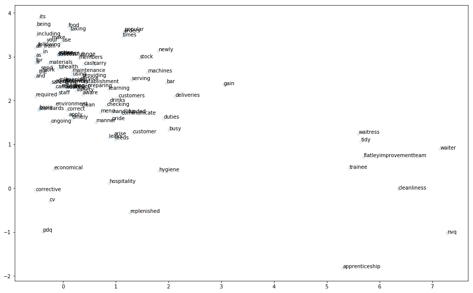

```python
plot_words_weights(words_weights.PC1.values[0:100],words_weights.PC2.values[0:100],words_weights.word.values[0:100])
```

Then let's take a look on a sequence in the group of 'above 150000'.

```python
sequences =test_desc_seq[bl_150000_max][16:17]
words_weights = cre_words_weights(sequences,embd_weights_2D,rev_word_idx)
words_weights = words_weights.drop_duplicates()
words_weights = words_weights.sort_values(by=['PC1'],ascending=False)

words_weights
```

|  | PC1 | PC2 | word |
| --- | --- | --- | --- |
| 111 | 1.086294 | 0.893822 | desirable |
| 67 | 0.899877 | 1.318860 | assist |
| 106 | 0.246579 | 1.957397 | processing |
| 52 | 0.185184 | 2.568892 | using |
| 41 | 0.176172 | 2.649115 | maintenance |
| 31 | 0.064720 | 3.241832 | job |
| 25 | 0.058833 | 1.925837 | skills |
| 47 | -0.024866 | 3.013358 | testing |
| 40 | -0.057110 | 3.405866 | 1 |
| 15 | -0.082570 | 2.732047 | to |
| 75 | -0.229003 | 2.597153 | products |
| 37 | -0.256540 | 2.400484 | involving |
| 10 | -0.346715 | 3.038741 | based |
| 34 | -0.352490 | 2.305791 | resource |
| 70 | -0.373862 | 3.084667 | in |
| 27 | -0.375210 | 2.669156 | work |
| 97 | -0.445065 | 0.773107 | sql |
| 71 | -0.457794 | 2.620268 | the |
| 7 | -0.509071 | 2.853485 | a |
| 23 | -0.515442 | 2.532245 | and |
| 110 | -0.523157 | -1.243303 | datamart |
| 42 | -0.564332 | 2.670066 | of |
| 74 | -0.569058 | 3.308217 | new |
| 32 | -0.572172 | 1.199883 | description |
| 14 | -0.601708 | 2.267926 | looking |
| 28 | -0.608037 | 3.187684 | on |
| 98 | -0.642793 | 0.761799 | perl |
| 20 | -0.648843 | 3.118305 | with |
| 57 | -0.649292 | -0.131090 | workflow |
| 33 | -0.662768 | 3.287868 | development |
| ... | ... | ... | ... |
| 2 | -0.804466 | 0.009554 | mxml |
| 30 | -0.813208 | 3.696494 | projects |
| 3 | -0.824337 | 1.852918 | java |
| 72 | -0.838856 | 2.655268 | implementation |
| 68 | -0.872831 | 3.269942 | project |
| 66 | -1.051192 | 0.539584 | etc |
| 62 | -1.124235 | -0.225417 | templates |
| 29 | -1.135844 | 2.238348 | upcoming |
| 104 | -1.207169 | -0.145338 | mdcs |
| 103 | -1.250073 | 3.129185 | exchange |
| 109 | -1.290048 | -1.454260 | osp |
| 39 | -1.307392 | 2.842768 | 3 |
| 64 | -1.315002 | 2.003693 | confirmation |
| 96 | -1.327419 | 0.927485 | unix |
| 95 | -1.373720 | 0.216736 | mxg |
| 21 | -1.439725 | 3.852788 | strong |
| 44 | -1.496956 | 3.305692 | infrastructure |
| 46 | -1.583983 | 1.296138 | configuration |
| 63 | -1.900247 | 1.546314 | swift |
| 88 | -1.917783 | 3.718217 | front |
| 51 | -1.919812 | 1.041093 | interfaces |
| 107 | -2.107767 | 1.609028 | batch |
| 5 | -2.313328 | 3.745051 | banking |
| 0 | -2.483741 | -1.141129 | murex |
| 8 | -2.491518 | 4.533143 | global |
| 105 | -2.542111 | -0.761187 | realtime |
| 12 | -2.873641 | 3.150468 | bank |
| 4 | -3.199278 | 4.051254 | investment |
| 9 | -3.272461 | 4.134350 | london |
| 6 | -3.869378 | 3.038465 | contract |

68 rows × 3 columns

From the dataframe above, sorted by the first dimension weight, we cannot find enough words at the top, along higher first dimension weights, as clues to identify the job position. But at the bottom, within the lower first dimension weights area, we can find words like 'mxml', 'java', 'unix', 'murex', 'bank', 'investment', 'london', which imply a person with IT technique background working with Murex platform for an investment bank in London.

Below is the full job description:

```python
test_desc[bl_150000_max][16:17]
```

```
21601    murex developer mxml java investment banking c...
Name: FullDescription, dtype: object
```

```python
desc_contexts[21601]
```

```
'murex developer mxml java investment banking contract a global london based investment bank arwe looking to hire a murex developer with strong mxml and java skills to work on upcoming projects. job description development resource on projects involving murex 3.1 maintenance of murex infrastructure …
```

Yes! The first line shows a London based investment bank is looking to hire a Murex developer!

From the study of the two cases, it seems that the neural network model gave higher first dimension weights to the key words when corresponding predicted salary is lower, and gave lower first dimension weights to the key words when corresponding predicted salary is higher.

But the study just based on two samples, that's too naive.

### Full Observations study via sequence representation

Let's make a scatter plot with all samples in the test data. Each data point on the plot with two properties: sequence weight, predicted salary.

One sequence means one specific description. We can extract all words first dimension weights in a sequence from the embedding layer, and use **the average weight as the sequence representation**. Using average weight is a simple way, but it can be the baseline and easy for finding patterns.

We will use the predicted salaries array as X values, and the sequence weights array as Y values.

```python
sequences_2D_weights = cre_sequence_avg_weight(test_desc_seq,embd_weights_2D)
sequences_2D_weights = np.asarray(sequences_2D_weights)
weight_2D_PC1 = sequences_2D_weights[:,0]
weight_2D_PC2 = sequences_2D_weights[:,1]
```

```
Text(0,0.5,'Sequence Weight')
```

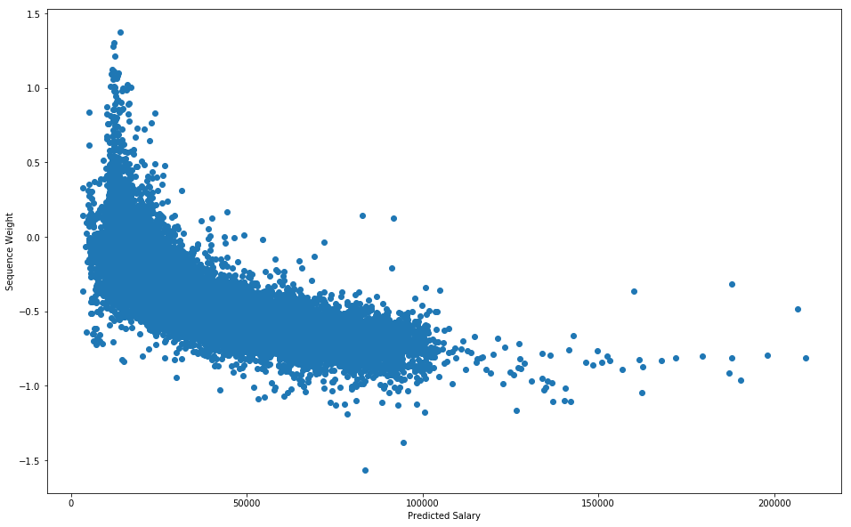

```python
fig1, ax1 = plt.subplots(figsize=(16,10))
ax1.scatter(y_pred_reshape, weight_2D_PC1)
ax1.set_xlabel('Predicted Salary')
ax1.set_ylabel('Sequence Weight')
```

The plot above shows a strong nonlinear negative relationship between the predicted salary and the first dimension weight!

Using `y_test` replacing predicted values, we can have a graph like the below. It looks not as smooth as the previous one, but still shows a nonlinear negative relationship existed.

```
Text(0,0.5,'Sequence Weight')
```

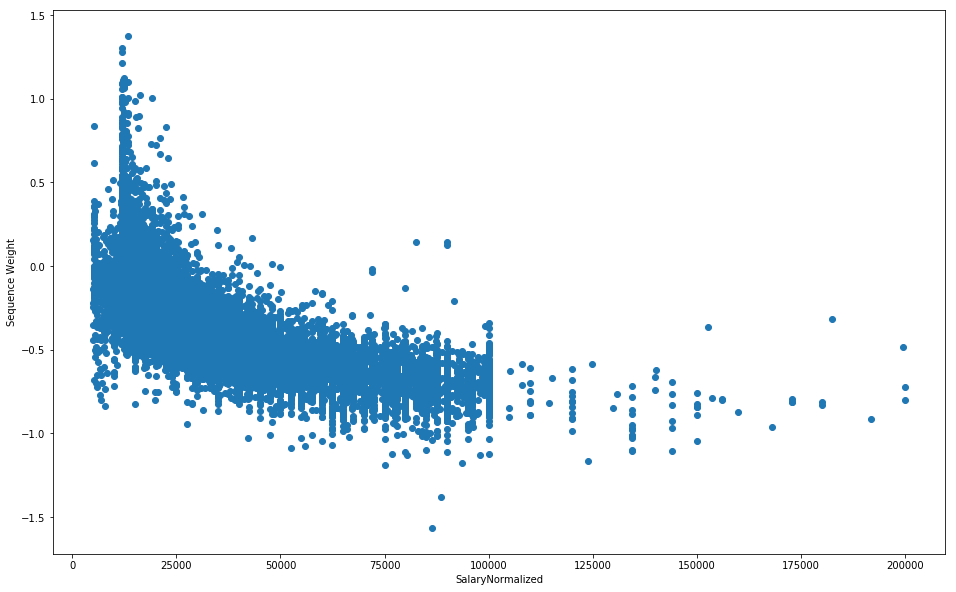

```python
fig1_2, ax1_2 = plt.subplots(figsize=(16,10))
ax1_2.scatter(y_test, weight_2D_PC1)
ax1_2.set_xlabel('SalaryNormalized')
ax1_2.set_ylabel('Sequence Weight')
```

How about the second dimension weight? We also make a plot for the predicted salary and the second dimension weight as below, and cannot find any meaningful relationship between them.

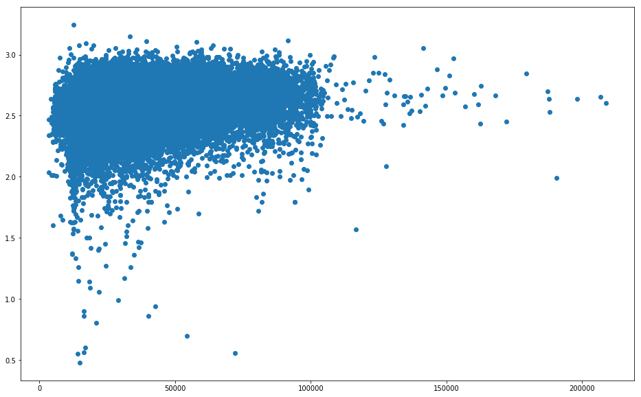

```python
fig2, ax2 = plt.subplots(figsize=(16,10))
ax2.scatter(y_pred_reshape, weight_2D_PC2)
```

### Extracting the new feature

Now, we can calculate two arrays of sequence weights for all observations in the original training data set and the test data set of the Kaggle competition, and use them as a new feature applying on other type of model such as random forest.

Did we extract a good enough feature? Let's test it!

```python
train_sequences_2D_weights = cre_sequence_avg_weight(pd.Series(desc_seq),embd_weights_2D)
train_sequences_2D_weights = np.asarray(train_sequences_2D_weights)
test2_desc=test.FullDescription.apply(clean_context)
test2_desc_seq = tokenizer.texts_to_sequences(test2_desc)
test_sequences_2D_weights = cre_sequence_avg_weight(pd.Series(test2_desc_seq),embd_weights_2D)
test_sequences_2D_weights = np.asarray(test_sequences_2D_weights)
np.save('data/train_weights.npy',train_sequences_2D_weights[:,0])
np.save('data/test_weights.npy',test_sequences_2D_weights[:,0])
```

## Testing the new feature

### Building a baseline RF model using 'Category' as X input

We firstly just use the 'Category' as the only feature. We use *Sklearn LabelEncoder* to encode the 'Category' variable as the X input.

Then we build a model with *Sklearn RandomForestRegressor*, training it with the encoded 'Category' values and the corresponding salary values, making a prediction with samples in the test data set. At last, we calculate the MAE between the predicted values and the benchmark values offered by the competition organizer.

```python
y_train = train.SalaryNormalized.values
le_Cat = LabelEncoder()
le_Cat.fit(train.Category.values)
train_Cat = le_Cat.transform(train.Category.values)
test_Cat = le_Cat.transform(test.Category.values)

X_Cat_train = train_Cat.reshape(-1,1)
X_Cat_test = test_Cat.reshape(-1,1)
rf_model_Cat = RandomForestRegressor(n_estimators=300,random_state=8033)
rf_model_Cat.fit(X_Cat_train,y_train)
pred_Cat = rf_model_Cat.predict(X_Cat_test)
np.mean(abs(pred_Cat-rf_bmk.SalaryNormalized.values))
```

```
8746.861945536326
```

The MAE is 8746.86194. The best score on the Leaderboard is 3464.55935. We don't pursue catching up with it. Our goal is verifying our new feature.

### Using the new feature on a similar RF model

The next turn is using the new feature we created before.

```python
X_DescWeight_train = np.load('data/train_weights.npy')
X_DescWeight_train = X_DescWeight_train.reshape((-1,1))
X_DescWeight_test = np.load('data/test_weights.npy')
X_DescWeight_test = X_DescWeight_test.reshape((-1,1))

rf_model_DescWeight = RandomForestRegressor(n_estimators=300,random_state=8034)
rf_model_DescWeight.fit(X_DescWeight_train,y_train)
pred_DescWeight = rf_model_DescWeight.predict(X_DescWeight_test)
np.mean(abs(pred_DescWeight-rf_bmk.SalaryNormalized.values))
```

```
8345.900007185095
```

This time, the MAE is 8345.90! It beats the performance of 'Category' a little bit under the similar models. That means we extracted a new feature as well as the 'Category' variable!

### Plot the relationship between the new feature and the target variable

Let's make two plots like before to see the relationship graphs for the new feature with the predicted values and the benchmark values.

```
Text(0,0.5,'Sequence Weight')
```

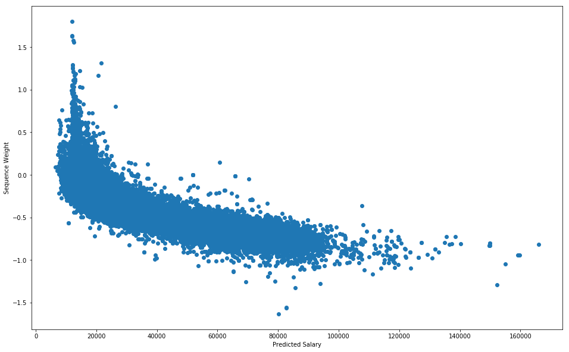

```python
fig3, ax3 = plt.subplots(figsize=(16,10))
ax3.scatter(pred_DescWeight, X_DescWeight_test)
ax3.set_xlabel('Predicted Salary')
ax3.set_ylabel('Sequence Weight')
```

```
Text(0,0.5,'Sequence Weight')
```

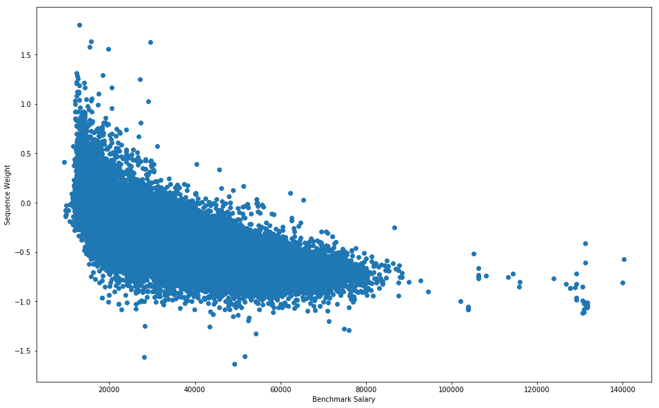

```python
fig4, ax4 = plt.subplots(figsize=(16,10))
ax4.scatter(rf_bmk.SalaryNormalized.values, X_DescWeight_test)
ax4.set_xlabel('Benchmark Salary')
ax4.set_ylabel('Sequence Weight')
```

### Exponential function relationship?

The relationship between the sequence weights and the predicted values is more convergent than that with benchmark values. But both of the two relationships are nonlinear negative. When we treat salary variable as Y, and the sequence weights as X, then it will look like some sort of exponential function graph.

### Applying Linear Model with Logarithm Transformation

Based on the plots before, we can try linear model for prediction with transforming the target variable via the numpy logarithmic function.

```python
Log_Y = np.log(y_train)
lm = LinearRegression()
lm.fit(X_DescWeight_train,Log_Y)
lm_pred = lm.predict(X_DescWeight_test)
lm_pred_exp = np.exp(lm_pred)
np.mean(abs(lm_pred_exp-rf_bmk.SalaryNormalized.values))
```

```
6326.918264168748
```

Bingo! The new feature applying on the simple linear model works very well! The score of 6326.91826 is much better than the random forest one!

## Discussion and further work

Let's review what we have done.

1. We used a simple neural network to train the embedding layer weights via predicting target salary variable.
2. And we use a few samples, which are beyond different salary levels, to find hints from the words and the corresponding weights.
3. Then we create sequence representation using average word weight.
4. We made a scatter plot between sequence weights and predicted salary values, finding the non-linear negative relationship.
5. We use the sequence weights as a new feature applied on a simple RandomForestRegressor model, comparing to use the 'Category' variable on a very similar model.
6. Finally, we applied the new feature to a linear model with the transformation of the `y` target variable. It achieved an impressive improvement on MAE score!

Through the experiment in this project, we found that there is a possible path using a neural network to learn and find patterns, or knowledges from data. Not just machine supervised by human, the two sides, human and machine, can teach each other and learn from each other.